# DeepakRamaswami_FinalSubmission

Final Submission:

SARIMAX and Prophet models

```python
import statsmodels
statsmodels.__version__
```

```
'0.13.2'
```

```python
#Import basic libraries
import pandas as pd
import warnings
import itertools
import numpy as np
import statsmodels.api as sm
import matplotlib.pyplot as plt
import seaborn as sns

from datetime import datetime
from sklearn.metrics import mean_squared_error
```

```python
# To ignore warnings
import warnings
import itertools
warnings.filterwarnings("ignore")
```

```python
# Loading data

df = pd.read_excel('MER_T12_06.xlsx')
df.head()
```

|  | MSN | YYYYMM | Value | Description |
| --- | --- | --- | --- | --- |
| 0 | CLEIEUS | 197301.0 | 72.076 | Coal Electric Power Sector CO2 Emissions |
| 1 | CLEIEUS | 197302.0 | 64.442 | Coal Electric Power Sector CO2 Emissions |
| 2 | CLEIEUS | 197303.0 | 64.084 | Coal Electric Power Sector CO2 Emissions |
| 3 | CLEIEUS | 197304.0 | 60.842 | Coal Electric Power Sector CO2 Emissions |
| 4 | CLEIEUS | 197305.0 | 61.798 | Coal Electric Power Sector CO2 Emissions |

```python
# Conversion of "YYYYMM" columnn into standard datetime format & making it as index
# We are using errors=’coerce’. It will replace all non-numeric values with NaN.

dateparse = lambda x: pd.to_datetime(x, format='%Y%m', errors = 'coerce')
df.index=dateparse(df["YYYYMM"])
df=df.drop(columns=["YYYYMM"])
print(df.head(), df.info())
```

```
<class 'pandas.core.frame.DataFrame'>
DatetimeIndex: 5094 entries, 1973-01-01 to 2016-07-01
Data columns (total 3 columns):
 #   Column       Non-Null Count  Dtype
---  ------       --------------  -----
 0   MSN          5094 non-null   object
 1   Value        5094 non-null   object
 2   Description  5094 non-null   object
dtypes: object(3)
memory usage: 159.2+ KB
                MSN   Value                               Description
YYYYMM
1973-01-01  CLEIEUS  72.076  Coal Electric Power Sector CO2 Emissions
1973-02-01  CLEIEUS  64.442  Coal Electric Power Sector CO2 Emissions
1973-03-01  CLEIEUS  64.084  Coal Electric Power Sector CO2 Emissions
1973-04-01  CLEIEUS  60.842  Coal Electric Power Sector CO2 Emissions
1973-05-01  CLEIEUS  61.798  Coal Electric Power Sector CO2 Emissions None
```

```python
# Drop rows in which index is NaN. This occurred where there was bad data (nonexistent month 13, for example)

ts = df[df.index.notna()==True]
```

```python
# Convert the emission value into a numeric value
def to_float(string):
    try:
        return float(string)
    except:
        return None

ts["Value"]=ts["Value"].apply(lambda x: to_float(x))
print(ts)
```

```
                MSN    Value                                       Description
YYYYMM
1973-01-01  CLEIEUS   72.076          Coal Electric Power Sector CO2 Emissions
1973-02-01  CLEIEUS   64.442          Coal Electric Power Sector CO2 Emissions
1973-03-01  CLEIEUS   64.084          Coal Electric Power Sector CO2 Emissions
1973-04-01  CLEIEUS   60.842          Coal Electric Power Sector CO2 Emissions
1973-05-01  CLEIEUS   61.798          Coal Electric Power Sector CO2 Emissions
...             ...      ...                                               ...
2016-03-01  TXEIEUS  115.997  Total Energy Electric Power Sector CO2 Emissions
2016-04-01  TXEIEUS  113.815  Total Energy Electric Power Sector CO2 Emissions
2016-05-01  TXEIEUS  129.440  Total Energy Electric Power Sector CO2 Emissions
2016-06-01  TXEIEUS  172.074  Total Energy Electric Power Sector CO2 Emissions
2016-07-01  TXEIEUS  201.958  Total Energy Electric Power Sector CO2 Emissions

[4707 rows x 3 columns]
```

```python
#Drop the missing value using dropna(inplace = True)
ts.dropna(inplace=True)
```

```python
### Clean up description names. We apply a lambda function to the dataframe.

def clean_description(description):
    cleaned_description = description.replace(" Electric Power Sector CO2 Emissions", "")
    return cleaned_description

cleanup = lambda x: clean_description(x)

ts["Description"]=ts["Description"].apply(lambda x: cleanup(x))

ts_grouped = ts.groupby('Description')
```

```python
###Slice the data to get the monthly total CO2 emissions of Natural Gas Electric Power Sector

timeseries_natgas = ts_grouped.get_group("Natural Gas")
timeseries_natgas = timeseries_natgas.drop(["MSN", "Description"], axis=1)
```

```python
 #Check 1st few rows of data
print(timeseries_natgas.head())
```

```
             Value
YYYYMM
1973-01-01  12.175
1973-02-01  11.708
1973-03-01  13.994
1973-04-01  14.627
1973-05-01  17.344
```

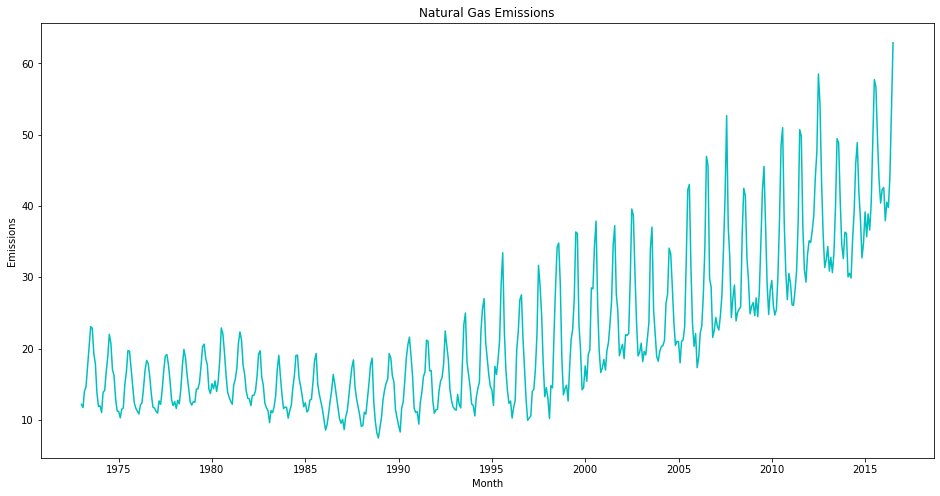

```python
# Date is now our index, while emissions value is the only non-index column. Visualizing the series.

plt.figure(figsize=(16,8))
plt.xlabel("Month")
plt.ylabel("Emissions")
plt.title("Natural Gas Emissions")
plt.plot(timeseries_natgas.index, timeseries_natgas.Value, color='c')
```

```python
# Split the data into train and test

ts_train = timeseries_natgas.loc['1973-01-01':'2014-07-01']
ts_test = timeseries_natgas.loc['2014-08-01':'2016-07-01']
print(ts_train)
print(ts_test)
print(ts_train.dtypes)

# We use the last 24 months as test data.
```

```
             Value
YYYYMM
1973-01-01  12.175
1973-02-01  11.708
1973-03-01  13.994
1973-04-01  14.627
1973-05-01  17.344
...            ...
2014-03-01  30.554
2014-04-01  29.885
2014-05-01  35.211
2014-06-01  39.228
2014-07-01  45.901

[499 rows x 1 columns]
             Value
YYYYMM
2014-08-01  48.871
2014-09-01  41.961
2014-10-01  38.286
2014-11-01  32.703
2014-12-01  34.800
2015-01-01  39.155
2015-02-01  35.668
2015-03-01  38.872
2015-04-01  36.610
2015-05-01  40.440
2015-06-01  48.920
2015-07-01  57.712
2015-08-01  56.662
2015-09-01  49.384
2015-10-01  43.680
2015-11-01  40.394
2015-12-01  42.270
2016-01-01  42.566
2016-02-01  37.918
2016-03-01  40.525
2016-04-01  39.763
2016-05-01  44.210
2016-06-01  53.567
2016-07-01  62.881
Value    float64
dtype: object
```

```python
# Testing Stationarity


import statsmodels.api as sm
from statsmodels.tsa.stattools import coint, adfuller
```

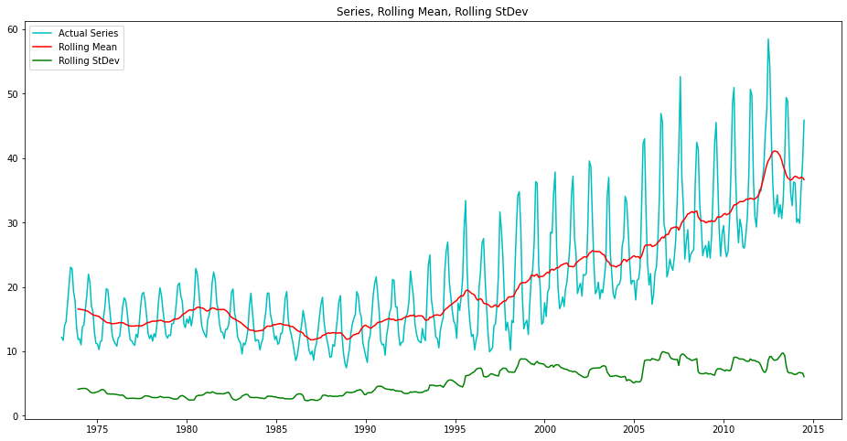

```python
# Calculate the rolling mean and standard deviation for a window of 12 observations

roll_mean = ts_train.rolling(window=12).mean()
roll_std = ts_train.rolling(window=12).std()

# Visualize the rolling mean and standard deviation

plt.figure(figsize=(16,8))
actual = plt.plot(ts_train, color='c', label='Actual Series')
rolling_mean = plt.plot(roll_mean, color='red', label='Rolling Mean')
rolling_std = plt.plot(roll_std, color='green', label='Rolling StDev')
plt.title('Series, Rolling Mean, Rolling StDev')
plt.legend()
plt.show()
```

```python
# Create function that uses adfuller test

def ad_fuller(dataset):
    print('ADF Test:')
    adftest = adfuller(dataset)
    adfoutput = pd.Series(adftest[0:4], index=['Test Statistic','p-value','Lags Used','No. of Observations'])
    for key, value in adftest[4].items():
        adfoutput['Critical Value (%s)' %(key)] = value
    print(adfoutput)

ad_fuller(ts_train)
```

```
ADF Test:
Test Statistic            0.435097
p-value                   0.982761
Lags Used                15.000000
No. of Observations     483.000000
Critical Value (1%)      -3.443962
Critical Value (5%)      -2.867543
Critical Value (10%)     -2.569967
dtype: float64
```

P value indicates that our series is not stationary. >0.05 so we fail to reject the null hypothesis: series is non-stationary.

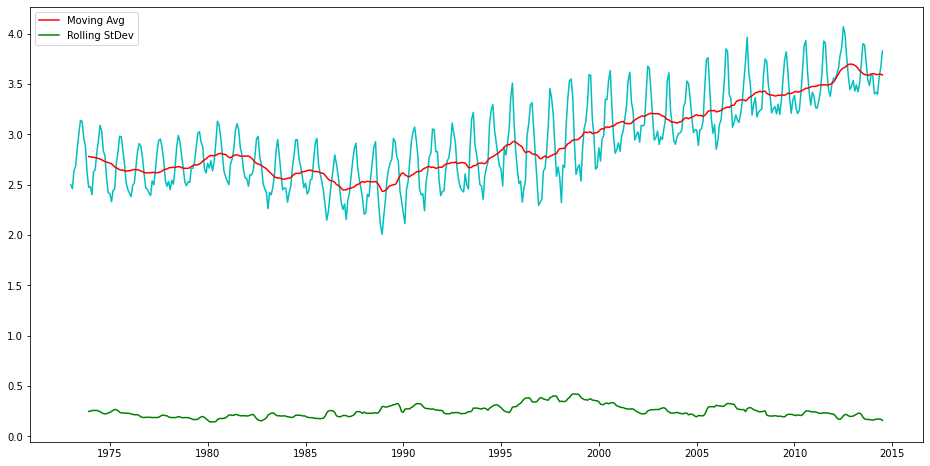

```
ADF Test:
Test Statistic            0.109704
p-value                   0.966717
Lags Used                17.000000
No. of Observations     481.000000
Critical Value (1%)      -3.444018
Critical Value (5%)      -2.867568
Critical Value (10%)     -2.569980
dtype: float64
```

```python
 # Visualize the rolling mean and standard deviation after using log transformation

ts_log = np.log(ts_train)
mavg = ts_log.rolling(window = 12).mean()
mstd = ts_log.rolling(window = 12).std()
plt.figure(figsize = (16,8))
plt.plot(ts_log, color = 'c')
plt.plot(mavg, color = 'r', label = "Moving Avg")
plt.plot(mstd, color = 'g', label = "Rolling StDev")
plt.legend()
plt.show()

ad_fuller(ts_log)
```

Log transformation doesn't help. There's still a trend to the rolling mean so we need to apply a shift and see if that works. The series does have constant variance though.

ADF test confirms what we see visually with a p-value>0.05 we fail to reject the null hypothesis and the series is non-stationary.

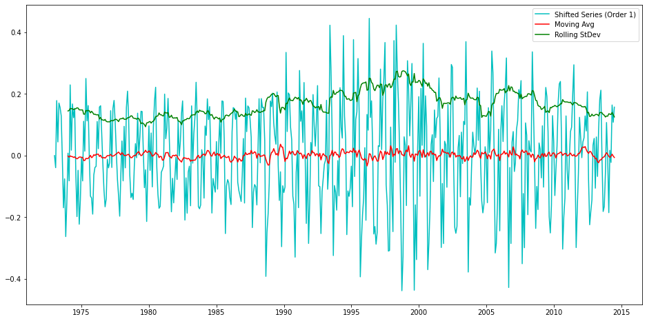

```python
# Try shifted series

ts_shift = ts_log-ts_log.shift(periods = 1)
mavg_shift = ts_shift.rolling(window = 12).mean()
mstd_shift = ts_shift.rolling(window = 12).std()
ts_shift = ts_shift.fillna(0) # Replace 1st difference with 0
plt.figure(figsize=(16,8))
plt.plot(ts_shift, color = 'c', label = "Shifted Series (Order 1)")
plt.plot(mavg_shift, color = 'red', label = "Moving Avg")
plt.plot(mstd_shift, color = 'green', label = "Rolling StDev")
plt.legend()
plt.show()
```

Visually it looks like the shifted series has constant mean and variance. We'll test this with ADF test.

```python
ad_fuller(ts_shift)
```

```
ADF Test:
Test Statistic           -4.925218
p-value                   0.000031
Lags Used                18.000000
No. of Observations     480.000000
Critical Value (1%)      -3.444047
Critical Value (5%)      -2.867580
Critical Value (10%)     -2.569987
dtype: float64
```

P-value < 0.05. We reject the null hypothesis. The series is stationary and we can proceed.

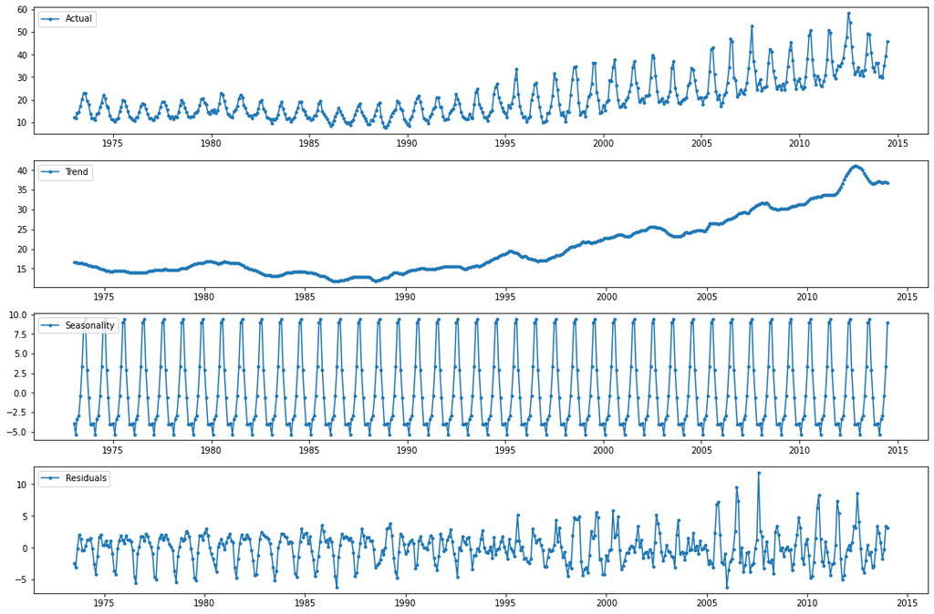

```python
# Time series decomposition

from statsmodels.tsa.seasonal import seasonal_decompose
decomp = seasonal_decompose(ts_train)

trend = decomp.trend
seasonal = decomp.seasonal
residual = decomp.resid

plt.figure(figsize=(15,10))
plt.subplot(411)
plt.plot(ts_train, label='Actual', marker='.')
plt.legend(loc='upper left')
plt.subplot(412)
plt.plot(trend, label='Trend', marker='.')
plt.legend(loc='upper left')
plt.subplot(413)
plt.plot(seasonal, label='Seasonality', marker='.')
plt.legend(loc='upper left')
plt.subplot(414)
plt.plot(residual, label='Residuals', marker='.')
plt.legend(loc='upper left')
plt.tight_layout()
```

We observe significant upward trend, and seasonality to the series.

Natural gas emissions seem to peak at mid-year. This could coincide with summer, ie increased energy use for air conditioning.

Plotting ACF and PACF to optimize SARIMAX model

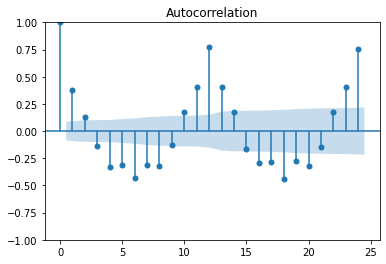

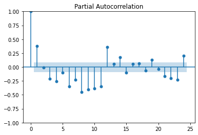

```python
from statsmodels.graphics.tsaplots import plot_acf,plot_pacf

plt.figure(figsize = (16,8))
plot_acf(ts_shift, lags = 24)
plt.show()
plot_pacf(ts_shift, lags = 24)
plt.show()
```

From the ACF plot, we infer that q=1; first lag for which the ACF crosses the upper confidence interval.

We also note autocorrelation at lags 12 and 24. This indicates annual seasonality which we'll use in our SARIMAX model.

Note: we have chosen not to include prior models in our final submission. We rejected AR, MA, and ARIMA models, and do not include them in this analysis (they are available in prior submissions).

```
 This problem is unconstrained.
```

[output not shown]

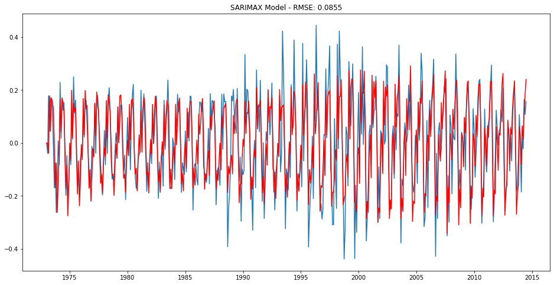

```python
from statsmodels.tsa.statespace.sarimax import SARIMAX

model_SARIMAX = SARIMAX(ts_shift, order=(1,1,1), seasonal_order=(1,1,1,12))
results_SARIMAX = model_SARIMAX.fit()
plt.figure(figsize=(16,8))
plt.plot(ts_shift)
plt.plot(results_SARIMAX.fittedvalues, color='red')
plt.title('SARIMAX Model - RMSE: %.4f'% mean_squared_error(results_SARIMAX.fittedvalues,ts_shift['Value'], squared=False))
plt.show()
```

```python
print(results_SARIMAX.aic)
```

```
-1004.4896196375104
```

```python
# Forecast on test data

predictionsx=pd.Series(results_SARIMAX.fittedvalues)
predictionsx_cumsum = predictionsx.cumsum()
predictionsx_log = pd.Series(ts_log['Value'].iloc[0], index=ts_log.index)
predictionsx_log = predictionsx_log.add(predictionsx_cumsum, fill_value=0)
predictions_SARIMAX = np.exp(predictionsx_log)
```

```python
forecasted_SARIMAX = results_SARIMAX.forecast(steps = 24)
forecasted_SARIMAX =forecasted_SARIMAX.cumsum()

last_value = ts_log['Value'].iloc[498]
forecastx_df = pd.DataFrame()
forecastx_df['Forecasted']=forecasted_SARIMAX
forecastx_df.index = forecasted_SARIMAX.index
forecastx_df['Forecasted']=forecastx_df['Forecasted']+last_value

forecastx_exp = np.exp(forecastx_df)
```

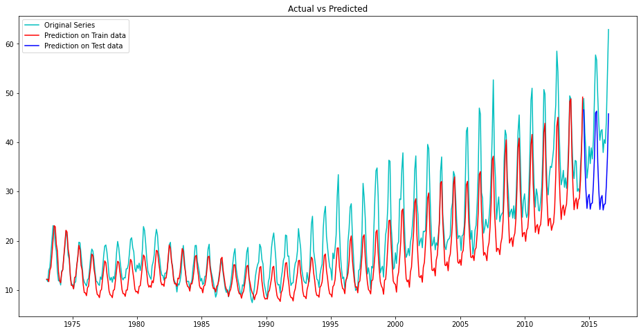

```python
plt.figure(figsize=(16,8))
plt.plot(timeseries_natgas, color = 'c', label = 'Original Series')
plt.plot(predictions_SARIMAX, color = 'r', label = 'Prediction on Train data')
plt.plot(forecastx_exp, label = 'Prediction on Test data', color='b')
plt.title('Actual vs Predicted')
plt.legend()
plt.show()
```

```python
error_sarimax = mean_squared_error(predictions_SARIMAX, ts_train, squared=False)
print(error_sarimax)

error_sarimax_predict = mean_squared_error(forecastx_exp, ts_test, squared=False)
print(error_sarimax_predict)
```

```
5.044497711023763
11.453791269882698
```

Previous models are unable to cope with the extreme seasonality of the data (these are not included here as they do not form a part of our final submission). SARIMAX is able to do so to some extent.

Still, the model doesn't fit the train data very well, and equally it doesn't fit the test data very well.

One thing we can try is a grid search of SARIMAX parameters.

```python
# Grid search to tune SARIMAX hyperparameters


p_list = range(0,3)
d_list = range(0,3)
q_list = range(0,3)

model_results=[]
for p in p_list:
    for d in d_list:
        for q in q_list:
            model_SARIMAX = SARIMAX(ts_shift, order=(1,1,1), seasonal_order=(p,d,q,12))
            results_SARIMAX = model_SARIMAX.fit(disp=False)
            model_results.append([mean_squared_error(results_SARIMAX.fittedvalues,ts_shift['Value'], squared = False),p,d,q])
```

```python
sorted(model_results, key = lambda x: x[0])
```

```
[[0.0853594960930355, 2, 1, 1],
 [0.08544574241951823, 1, 1, 2],
 [0.08545631240575262, 2, 1, 2],
 [0.08550128547202689, 1, 1, 1],
 [0.08550699843969879, 0, 1, 2],
 [0.08551719233224571, 0, 1, 1],
 [0.08613406185492548, 2, 0, 2],
 [0.08629658847013758, 2, 0, 1],
 [0.0863219055076913, 1, 0, 2],
 [0.08637285631747266, 1, 0, 1],
 [0.08958576575426719, 2, 1, 0],
 [0.09057834292889407, 0, 2, 2],
 [0.09058705845441, 1, 2, 2],
 [0.09215257227777063, 2, 0, 0],
 [0.09261596671246704, 1, 1, 0],
 [0.09396609562311979, 2, 2, 1],
 [0.09550001813477074, 2, 2, 2],
 [0.09690032255481765, 1, 2, 1],
 [0.10205189447704774, 1, 0, 0],
 [0.10618383620377565, 0, 1, 0],
 [0.11041345677433119, 0, 2, 1],
 [0.11500204331930616, 0, 0, 2],
 [0.11869925046099153, 2, 2, 0],
 [0.12731100695736666, 0, 0, 1],
 [0.13334019840908976, 1, 2, 0],
 [0.15137045410910158, 0, 0, 0],
 [0.18135386894549985, 0, 2, 0]]
```

We used grid search with various parameter combinations to optimize the SARIMAX model.

However, we see that our default choice of p,d,q = 1 is close to optimal-grid search does not confer any meaningful advantage.

Overall, the SARIMAX model is our best fit so far, but is not a very good fit.

We will try Prophet-an additive model specifically designed to handle extremely seasonal data.

```
Importing plotly failed. Interactive plots will not work.
INFO:prophet:Disabling weekly seasonality. Run prophet with weekly_seasonality=True to override this.
INFO:prophet:Disabling daily seasonality. Run prophet with daily_seasonality=True to override this.
```

[output not shown]

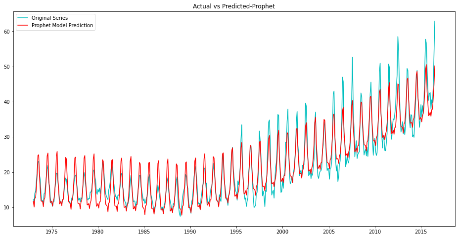

```python
from prophet import Prophet

prophet_model = Prophet()
ts_train_prophet_format=ts_train.copy(deep=True)
ts_train_prophet_format["ds"]=ts_train_prophet_format.index
ts_train_prophet_format.rename(columns={"Value":"y"}, inplace=True)
prophet_model.fit(ts_train_prophet_format) # Fit Prophet on training data
future = prophet_model.make_future_dataframe(periods=24, freq="MS")
forecast_prophet = prophet_model.predict(future)
forecast_df_prophet = forecast_prophet[['ds', 'yhat']]
forecast_df_prophet.index=forecast_df_prophet['ds']
forecast_df_prophet.drop(columns=['ds'], inplace=True)


plt.figure(figsize=(16,8))
plt.plot(timeseries_natgas, color = 'c', label = 'Original Series')
plt.plot(forecast_df_prophet, color = 'r', label = 'Prophet Model Prediction')
plt.title('Actual vs Predicted-Prophet')
plt.legend()
plt.show()
```

```python
# Check Prophet RMSE

prophet_fit = forecast_df_prophet.loc['1973-01-01':'2014-07-01']
error_prophet = mean_squared_error(prophet_fit, ts_train, squared=False)
print(error_prophet)

prophet_predict = forecast_df_prophet.loc['2014-08-01':'2016-07-01']
error_prophet_predict = mean_squared_error(prophet_predict, ts_test, squared=False)
print(error_prophet_predict)
```

```
2.8094499467323493
4.955971944508204
```

Prophet provides a good fit, as we can see visually. RMSE is significantly lower on training and test data than it is for SARIMAX, our next-best-fitting model.

This is the best of all models we've used so far, and will feature in our final submission.